# 산업공학특론I_13-14주차_산업데이터분석

2024-05-29

## [데이터 분석 개요]

### 1. 대상 데이터: 다단계 공정 데이터셋

(https://www.kaggle.com/datasets/supergus/multistage-continuousflow-manufacturing-process)

미시간 주 디트로이트 근처의 실제 생산 라인 내에서 여러 위치, 여러 생산 라인에 대하여 계측한 데이터

다양한 입력 데이터로부터 라인의 출력 특정 속성을 예측하기 위한 목적으로 수집

해당 공정 라인은 병렬 및 직렬 단계로 구성된 고속 연속 제조 공정으로, 다음과 같은 구조를 가짐

- Stage 1에서는 M1, M2, M3 기계가 병렬로 작동하며, 이들의 출력이 결합기로 전달
- 결합기에서 출력되는 Stage 1에 대한 예측치는 제작된 제품의 외부 표면을 둘러싼 15개의 위치에서 측정
- 다음으로, M4와 M5가 직렬로 처리하는 Stage 2로 이동
- M5 작동 후에는 동일한 15개의 위치에 대한 Stage 2의 측정이 이루어짐

* Oleghe, O. (2020). A predictive noise correction methodology for manufacturing process datasets. Journal of Big Data, 7(1), 89.

### 2. 분석 절차

데이터 탐색 및 전처리 / 특징 추출 및 차원 축소 / 모델 학습 및 평가 순서로 3단계로 나누어 분석 진행

2단계 공정인 관계로 Stage 1에 대한 예측모델, Stage 2에 대한 예측모델을 2단계로 모델링할 것 (이 때, Stage 2의 결과는 Stage 1에 영향을 받음)

원래 Stage 1, Stage 2에 대한 예측값은 각각 15개씩이지만, 본 강의에서는 다변량 예측을 다루지 않는 관계로 각 Stage에 대한 평균값을 종속변수로 설정

팀별로 작업을 수행하며, 작업 코드는 팀장의 Github에 Push하여 공유, 통찰력 있는 분석 기법 발굴 시 모두와 공유

가이드로 제공된 참고문헌을 바탕으로 다양한 방법론으로 분석을 수행

## [데이터 분석]

### 1. 데이터 탐색 및 전처리

- 데이터의 전반적인 분포, 특징을 파악하기 위한 기초 분석 진행
- 다양한 전처리 방법론을 활용하여 데이터를 정제 (e.g. 필요없는 변수 및 이상치/노이즈 제거 또는 보정, 표준화 등)
- 데이터 전처리 순서 (학습, 테스트셋 분할 전후)를 꼼꼼히 살펴보고 진행할 것

```r
dat <- read.csv("E:/Course/2024_lec_rstudio/실습/프로젝트실습/산업공학특론I_13-14주차_데이터.csv")
head(dat)
```

```
##            time_stamp AmbientConditions.AmbientHumidity.U.Actual
## 1 2019-03-06 10:52:33                                      17.24
## 2 2019-03-06 10:52:34                                      17.24
## 3 2019-03-06 10:52:35                                      17.24
## 4 2019-03-06 10:52:36                                      17.24
## 5 2019-03-06 10:52:37                                      17.24
## 6 2019-03-06 10:52:38                                      17.24
##   AmbientConditions.AmbientTemperature.U.Actual Machine1.RawMaterial.Property1
## 1                                         23.53                          11.54
## 2                                         23.53                          11.54
## 3                                         23.53                          11.54
## 4                                         23.53                          11.54
## 5                                         23.53                          11.54
## 6                                         23.53                          11.54
##   Machine1.RawMaterial.Property2 Machine1.RawMaterial.Property3
```

[output cut: 405 more lines]

```r
dim(dat)
```

```
## [1] 14088   116
```

```r
# timestamp 변수 삭제
dat <- dat[,-1]

# unique값 적은 변수 살펴보기
# temp <- c(1,1,1,2,3)
# unique(temp)
uniqval <- function(x){length(unique(x))}
dat_uniq <- apply(dat,2,uniqval)
apply(dat[,dat_uniq<10], 2, unique)
```

```
## $Machine1.RawMaterial.Property1
## [1] 11.54 12.90 12.59 12.22
##
## $Machine1.RawMaterial.Property2
## [1] 200 215 236 201
##
## $Machine1.RawMaterial.Property3
## [1]  963.00 1027.43  980.53  601.11 1048.06
##
## $Machine1.RawMaterial.Property4
## [1] 247 251 257 252
##
## $Machine2.RawMaterial.Property1
## [1] 12.59 12.85
##
## $Machine2.RawMaterial.Property2
## [1] 236 241
##
## $Machine2.RawMaterial.Property3
## [1] 601.11 556.70
##
## $Machine2.RawMaterial.Property4
## [1] 257 256
##
## $Machine3.RawMaterial.Property1
## [1] 9.02 9.86 8.83
##
## $Machine3.RawMaterial.Property2
## [1] 186 192 221
##
## $Machine3.RawMaterial.Property3
## [1] 421.16 408.97 433.18
##
## $Machine3.RawMaterial.Property4
## [1] 200 202 205
##
## $Stage1.Output.Measurement0.U.Setpoint
## [1] 13.75  0.00
##
## $Stage1.Output.Measurement1.U.Setpoint
```

[output cut: 70 more lines]

```
##
## $Stage2.Output.Measurement10.U.Setpoint
## [1] 7.93
##
## $Stage2.Output.Measurement11.U.Setpoint
## [1] 5.65
##
## $Stage2.Output.Measurement12.U.Setpoint
## [1] 1.85
##
## $Stage2.Output.Measurement13.U.Setpoint
## [1] 2.89
##
## $Stage2.Output.Measurement14.U.Setpoint
## [1] 11.71
```

```r
# setpoint 관련 변수를 면밀히 조사
setidx <- grep('Setpoint', colnames(dat))

# par(mfrow=c(3,5))
# for (idx in setidx){
#   plot(dat[,idx-1], dat[,idx], xlab=colnames(dat)[idx-1], ylab=colnames(dat)[idx])
# }

apply(dat[,setidx], 2, table)
```

```
## $Stage1.Output.Measurement0.U.Setpoint
##
##     0 13.75
##    56 14032
##
## $Stage1.Output.Measurement1.U.Setpoint
##
##     0 22.74
##    56 14032
##
## $Stage1.Output.Measurement2.U.Setpoint
##
##     0 13.02
##    56 14032
##
## $Stage1.Output.Measurement3.U.Setpoint
##
##     0 21.88
##    56 14032
##
## $Stage1.Output.Measurement4.U.Setpoint
##
##     0 32.55
##    56 14032
##
## $Stage1.Output.Measurement5.U.Setpoint
##
##     0  2.74
##    56 14032
##
## $Stage1.Output.Measurement6.U.Setpoint
##
##     0  4.25
##    56 14032
##
## $Stage1.Output.Measurement7.U.Setpoint
##
##     0  2.97
##    56 14032
##
```

[output cut: 94 more lines]

```
##
## $Stage2.Output.Measurement12.U.Setpoint
##
##  1.85
## 14088
##
## $Stage2.Output.Measurement13.U.Setpoint
##
##  2.89
## 14088
##
## $Stage2.Output.Measurement14.U.Setpoint
##
## 11.71
## 14088
```

```r
dat_set0 <- dat[dat[,setidx[1]]==0, ]
apply(dat_set0[,setidx], 2, table) # 0 제외 시 단일값 확인
```

```
##  Stage1.Output.Measurement0.U.Setpoint  Stage1.Output.Measurement1.U.Setpoint
##                                     56                                     56
##  Stage1.Output.Measurement2.U.Setpoint  Stage1.Output.Measurement3.U.Setpoint
##                                     56                                     56
##  Stage1.Output.Measurement4.U.Setpoint  Stage1.Output.Measurement5.U.Setpoint
##                                     56                                     56
##  Stage1.Output.Measurement6.U.Setpoint  Stage1.Output.Measurement7.U.Setpoint
##                                     56                                     56
##  Stage1.Output.Measurement8.U.Setpoint  Stage1.Output.Measurement9.U.Setpoint
##                                     56                                     56
## Stage1.Output.Measurement10.U.Setpoint Stage1.Output.Measurement11.U.Setpoint
##                                     56                                     56
## Stage1.Output.Measurement12.U.Setpoint Stage1.Output.Measurement13.U.Setpoint
##                                     56                                     56
## Stage1.Output.Measurement14.U.Setpoint  Stage2.Output.Measurement0.U.Setpoint
##                                     56                                     56
##  Stage2.Output.Measurement1.U.Setpoint  Stage2.Output.Measurement2.U.Setpoint
##                                     56                                     56
##  Stage2.Output.Measurement3.U.Setpoint  Stage2.Output.Measurement4.U.Setpoint
##                                     56                                     56
##  Stage2.Output.Measurement5.U.Setpoint  Stage2.Output.Measurement6.U.Setpoint
##                                     56                                     56
##  Stage2.Output.Measurement7.U.Setpoint  Stage2.Output.Measurement8.U.Setpoint
##                                     56                                     56
##  Stage2.Output.Measurement9.U.Setpoint Stage2.Output.Measurement10.U.Setpoint
##                                     56                                     56
## Stage2.Output.Measurement11.U.Setpoint Stage2.Output.Measurement12.U.Setpoint
##                                     56                                     56
## Stage2.Output.Measurement13.U.Setpoint Stage2.Output.Measurement14.U.Setpoint
##                                     56                                     56
```

```r
# 이상치 제거 (제거 대신 다른 방법을 쓸 수도 있음)
dat <- dat[dat[,setidx[1]]!=0, ]
apply(dat[,setidx],2,uniqval)
```

```
##  Stage1.Output.Measurement0.U.Setpoint  Stage1.Output.Measurement1.U.Setpoint
##                                      1                                      1
##  Stage1.Output.Measurement2.U.Setpoint  Stage1.Output.Measurement3.U.Setpoint
##                                      1                                      1
##  Stage1.Output.Measurement4.U.Setpoint  Stage1.Output.Measurement5.U.Setpoint
##                                      1                                      1
##  Stage1.Output.Measurement6.U.Setpoint  Stage1.Output.Measurement7.U.Setpoint
##                                      1                                      1
##  Stage1.Output.Measurement8.U.Setpoint  Stage1.Output.Measurement9.U.Setpoint
##                                      1                                      1
## Stage1.Output.Measurement10.U.Setpoint Stage1.Output.Measurement11.U.Setpoint
##                                      1                                      1
## Stage1.Output.Measurement12.U.Setpoint Stage1.Output.Measurement13.U.Setpoint
##                                      1                                      1
## Stage1.Output.Measurement14.U.Setpoint  Stage2.Output.Measurement0.U.Setpoint
##                                      1                                      1
##  Stage2.Output.Measurement1.U.Setpoint  Stage2.Output.Measurement2.U.Setpoint
##                                      1                                      1
##  Stage2.Output.Measurement3.U.Setpoint  Stage2.Output.Measurement4.U.Setpoint
##                                      1                                      1
##  Stage2.Output.Measurement5.U.Setpoint  Stage2.Output.Measurement6.U.Setpoint
##                                      1                                      1
##  Stage2.Output.Measurement7.U.Setpoint  Stage2.Output.Measurement8.U.Setpoint
##                                      1                                      1
##  Stage2.Output.Measurement9.U.Setpoint Stage2.Output.Measurement10.U.Setpoint
##                                      1                                      1
## Stage2.Output.Measurement11.U.Setpoint Stage2.Output.Measurement12.U.Setpoint
##                                      1                                      1
## Stage2.Output.Measurement13.U.Setpoint Stage2.Output.Measurement14.U.Setpoint
##                                      1                                      1
```

```r
# Setpoint 변수 삭제
dat <- dat[,-setidx]

# 다변량 회귀분석이 아닌 관계로 종속변수 평균화
depidx1 <- grep('Stage1.Output', colnames(dat))
depidx2 <- grep('Stage2.Output', colnames(dat))
dat$Stage1_Output <- apply(dat[,depidx1],1,mean)
dat$Stage2_Output <- apply(dat[,depidx2],1,mean)
dat <- dat[,-c(depidx1,depidx2)]
head(dat)
```

```
##   AmbientConditions.AmbientHumidity.U.Actual
## 1                                      17.24
## 2                                      17.24
## 3                                      17.24
## 4                                      17.24
## 5                                      17.24
## 6                                      17.24
##   AmbientConditions.AmbientTemperature.U.Actual Machine1.RawMaterial.Property1
## 1                                         23.53                          11.54
## 2                                         23.53                          11.54
## 3                                         23.53                          11.54
## 4                                         23.53                          11.54
## 5                                         23.53                          11.54
## 6                                         23.53                          11.54
##   Machine1.RawMaterial.Property2 Machine1.RawMaterial.Property3
```

[output cut: 202 more lines]

```r
# 종속변수 기반 이상치 제거/보정
library(MASS)
# outlier <- function(target){ # 방법 1) IQR
#   iqr <- quantile(target, c(0.25, 0.75))
#   (target < iqr[1] - 1.5 * diff(iqr))|(target > iqr[2] + 1.5 * diff(iqr))
# }
# outlier <- function(target){ # 방법 2) z-score
#   z <- (target - mean(target)) / sd(target)
#   abs(z) > 3
# }
outlier <- function(target){ # 방법 3) Cook's distance
  temp <- dat[,-((ncol(dat)-1):ncol(dat))]
  temp <- cbind(temp, target)
  reg <- lm(target ~ ., data=temp)
  cd <- cooks.distance(reg)
  cd > 4 / (nrow(temp) - length(reg$coef))
}

### 1. 이상치 제거
dat <- dat[!(outlier(dat$Stage1_Output) & outlier(dat$Stage2_Output)),]

### 2. 이상치 보정 (평균치 또는 중앙값)
dat[(outlier(dat$Stage1_Output) & outlier(dat$Stage2_Output)),] <- apply(dat[!(outlier(dat$Stage1_Output) & outlier(dat$Stage2_Output)),],2,mean)
apply(dat[!(outlier(dat$Stage1_Output) & outlier(dat$Stage2_Output)),],2,median)
```

```
##         AmbientConditions.AmbientHumidity.U.Actual
##                                          15.120000
##      AmbientConditions.AmbientTemperature.U.Actual
##                                          23.930000
##                     Machine1.RawMaterial.Property1
##                                          11.540000
##                     Machine1.RawMaterial.Property2
##                                         200.000000
##                     Machine1.RawMaterial.Property3
##                                         980.530000
##                     Machine1.RawMaterial.Property4
##                                         247.000000
##       Machine1.RawMaterialFeederParameter.U.Actual
##                                        1264.550000
##                 Machine1.Zone1Temperature.C.Actual
##                                          72.000000
##                 Machine1.Zone2Temperature.C.Actual
##                                          72.000000
##                    Machine1.MotorAmperage.U.Actual
##                                          71.980000
##                         Machine1.MotorRPM.C.Actual
##                                          10.730000
##                 Machine1.MaterialPressure.U.Actual
##                                         416.860000
##              Machine1.MaterialTemperature.U.Actual
##                                          81.300000
##              Machine1.ExitZoneTemperature.C.Actual
##                                          75.000000
##                     Machine2.RawMaterial.Property1
##                                          12.850000
##                     Machine2.RawMaterial.Property2
##                                         241.000000
##                     Machine2.RawMaterial.Property3
##                                         556.700000
##                     Machine2.RawMaterial.Property4
##                                         256.000000
##       Machine2.RawMaterialFeederParameter.U.Actual
##                                         203.170000
##                 Machine2.Zone1Temperature.C.Actual
##                                          68.990000
```

[output cut: 59 more lines]

```
##                                         290.000000
##                     Machine5.Temperature3.C.Actual
##                                         270.000000
##                     Machine5.Temperature4.C.Actual
##                                         242.700000
##                     Machine5.Temperature5.C.Actual
##                                         245.000000
##                     Machine5.Temperature6.C.Actual
##                                          63.400000
##                  Machine5.ExitTemperature.U.Actual
##                                         155.600000
##                                      Stage1_Output
##                                          10.121333
##                                      Stage2_Output
##                                           8.019333
```

```r
# 변수명 변경
colnames(dat) <- gsub('.C[.]Actual','',colnames(dat))
colnames(dat) <- gsub('.U[.]Actual','',colnames(dat))
colnames(dat) <- gsub('[.]','_',colnames(dat))
colnames(dat) <- gsub('Machine','M',colnames(dat))
colnames(dat)
```

```
##  [1] "AmbientConditions_AmbientHumidity"
##  [2] "AmbientConditions_AmbientTemperature"
##  [3] "M1_RawMaterial_Property1"
##  [4] "M1_RawMaterial_Property2"
##  [5] "M1_RawMaterial_Property3"
##  [6] "M1_RawMaterial_Property4"
##  [7] "M1_RawMaterialFeederParameter"
##  [8] "M1_Zone1Temperature"
##  [9] "M1_Zone2Temperature"
## [10] "M1_MotorAmperage"
## [11] "M1_MotorRPM"
## [12] "M1_MaterialPressure"
## [13] "M1_MaterialTemperature"
## [14] "M1_ExitZoneTemperature"
## [15] "M2_RawMaterial_Property1"
```

[output cut: 42 more lines]

```r
# 트레인, 테스트셋 분할
library(caret)
```

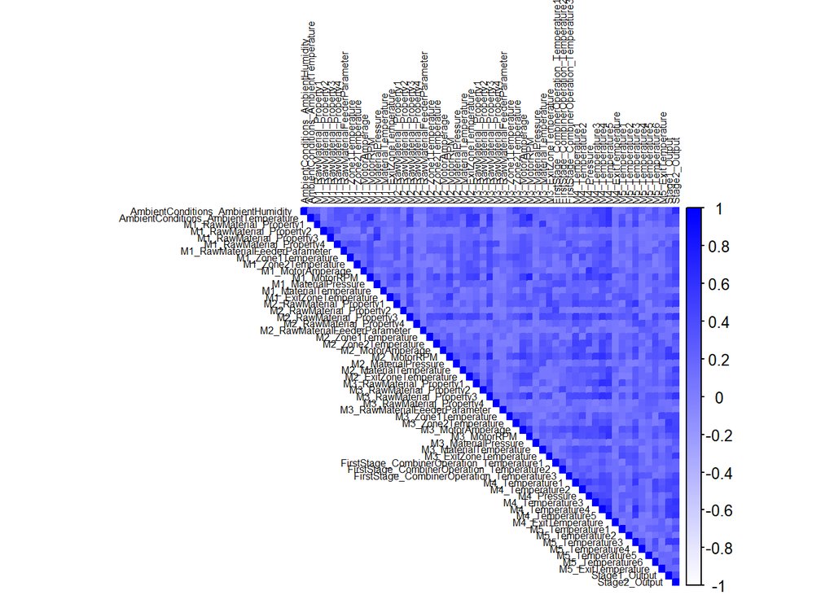

```r
set.seed(0)
trainidx <- sample(1:nrow(dat), 0.7*nrow(dat))
trainset <- dat[trainidx,]
testset <- dat[-trainidx,]

# 표준화
depidx <- (ncol(trainset)-1):ncol(trainset)
scaling <- preProcess(trainset[, -depidx], method = c("center", "scale"))

traintarget <- trainset[,depidx]
trainsc <- predict(scaling, trainset[, -depidx])
trainsc <- cbind(trainsc, traintarget)

testtarget <- testset[,depidx]
testsc <- predict(scaling, testset[, -depidx])
testsc <- cbind(testsc, testtarget)

# 상관분석
library(corrplot)
par(mfrow=c(1,1))
corr <- cor(trainsc)
col <- colorRampPalette(c('white','blue'))
corrplot(abs(corr), method='color', col=col(200), type='upper',tl.cex = 0.5, tl.col='black')
```

```r
targetcor <- corr[,ncol(corr)]
targetcor <- targetcor[targetcor!=1 & abs(targetcor)>0.6]
# 상관성이 0.6이 이상인 대상이 적어 이를 무시하고 전체 데이터를 대상으로 pca 진행
data.frame(correlation=targetcor[order(abs(targetcor), decreasing=T)])
```

```
##                                   correlation
## AmbientConditions_AmbientHumidity   0.6613504
## M4_Temperature5                    -0.6092791
```

```r
# 공정별 데이터셋 정의
### Stage1의 경우 1차 공정 변수만 활용하기 때문에 별도로 변수 추출
extract <- function(data, type){
  if (type==1){ data[,c(1:41,56)] } else if (type==2) { data[,-56] }
}

trainsc1 <- extract(trainsc,1); trainsc2 <- extract(trainsc,2)
testsc1 <- extract(testsc,1); testsc2 <- extract(testsc,2)
```

### 2. 특징 추출 및 차원 축소

- 전처리가 이루어진 데이터로부터 특성을 재정의하거나 차원 축소 기법을 적용
- 신규 변수 또는 축소된 차원으로 효과적인 예측을 수행하기 위한 방안 도출

```r
library(factoextra)
```

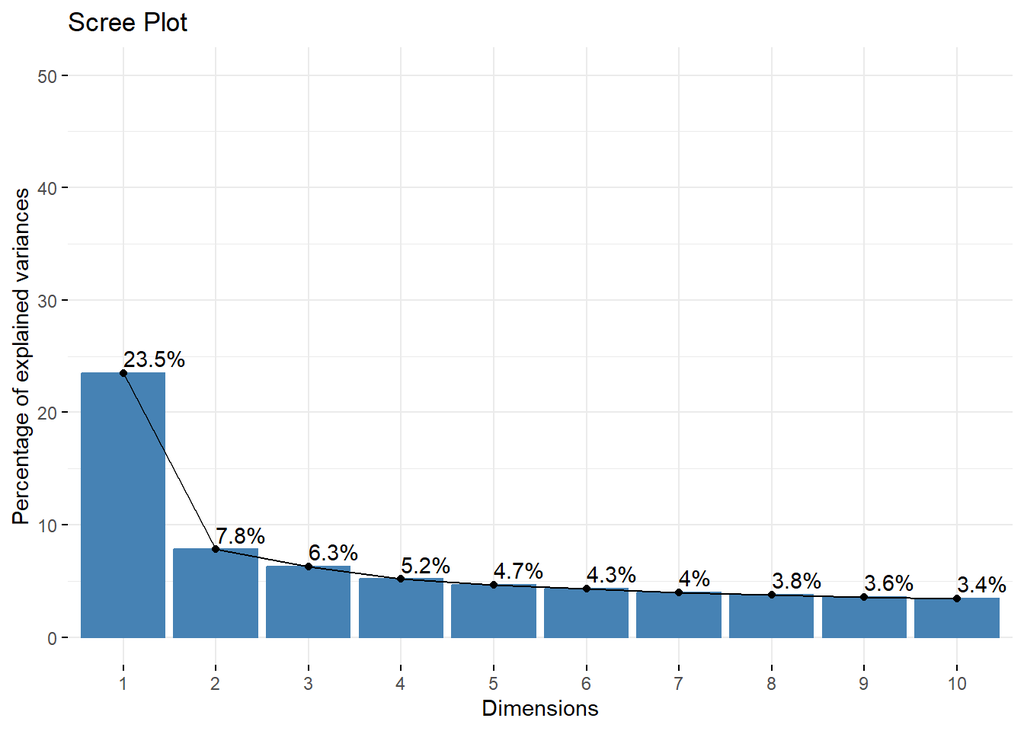

```r
library(ggplot2)


# PCA를 통한 차원 축소
pca <- prcomp(trainsc1[,1:41], center = TRUE, scale. = TRUE)
fviz_eig(pca, addlabels = TRUE, ylim = c(0, 50)) + ggtitle("Scree Plot")
```

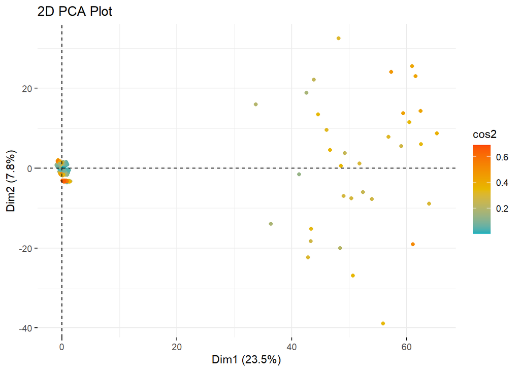

```r
fviz_pca_ind(pca,
             geom.ind = "point",
             col.ind = "cos2", # Color by the quality of representation
             gradient.cols = c("#00AFBB", "#E7B800", "#FC4E07"),
             repel = TRUE) + ggtitle("2D PCA Plot")
```

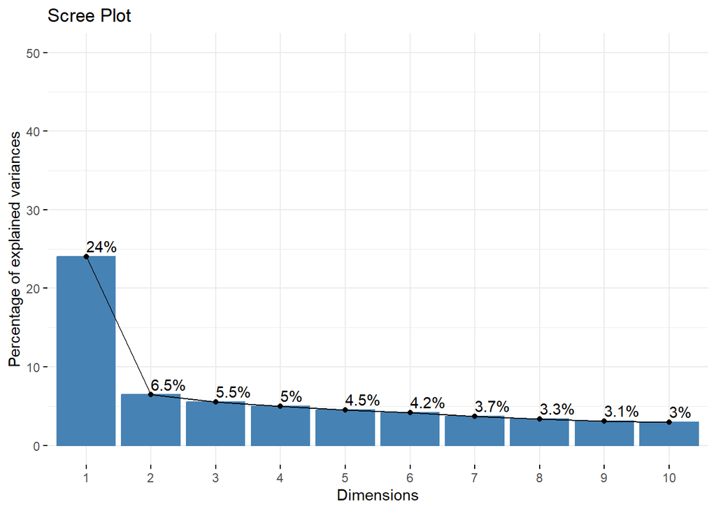

```r
train1pca <- cbind(pca$x[, 1:5], traintarget[1])
test1pca <- cbind(predict(pca, testsc1[,1:41])[, 1:5], testtarget[1])

pca <- prcomp(trainsc2[,1:55], center = TRUE, scale. = TRUE)
fviz_eig(pca, addlabels = TRUE, ylim = c(0, 50)) + ggtitle("Scree Plot")
```

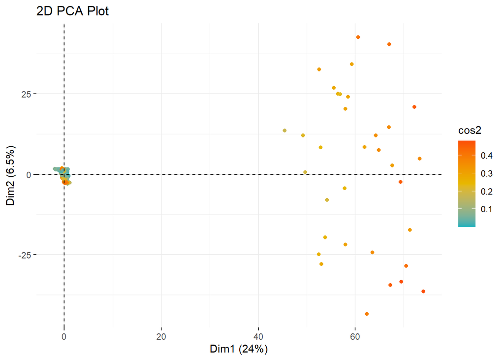

```r
fviz_pca_ind(pca,
             geom.ind = "point",
             col.ind = "cos2", # Color by the quality of representation
             gradient.cols = c("#00AFBB", "#E7B800", "#FC4E07"),
             repel = TRUE) + ggtitle("2D PCA Plot")
```

```r
train2pca <- cbind(pca$x[, 1:5], traintarget[2])
test2pca <- cbind(predict(pca, testsc2[,1:55])[, 1:5], testtarget[2])
```

### 3. 모델 학습 및 평가

- Stage 1, Stage 2에 대한 예측 모델을 수립할 것
- 이 때, 각 Stage는 연결되어 있으며 Stage 2는 Stage 1의 영향을 받음

```r
library(rpart)
```

```r
library(rpart.plot)
library(caret)
library(Metrics)
evaluate <- function(modelnm, model1, model2, test1, test2){

  pred1 <- predict(model1, newdata=test1)
  if (is.matrix(pred1)) {
    pred1 <- as.vector(pred1)  # 예측 결과를 벡터로 변환
  }
  test2$stage1_ouput_exp <- pred1
  pred2 <- predict(model2, newdata=test2)

  print(modelnm)
  result <- c(modelnm,
              mae(pred1, testsc1$Stage1_Output),
              rmse(pred1, testsc1$Stage1_Output),
              mse(pred1, testsc1$Stage1_Output),
              mae(pred2, testsc2$Stage2_Output),
              rmse(pred2, testsc2$Stage2_Output),
              mse(pred2, testsc2$Stage2_Output))

  names(result) <- c("Model","Stage1 MAE","Stage1 RMSE","Stage1 MSE",
                     "Stage2 MAE","Stage2 RMSE","Stage2 MSE")
  print(result)
}

train_control <- trainControl(method="cv", number=10)

#Decision Tree
decistion_tree <- function(train1, train2){

  train_control <- trainControl(method="cv", number=10)
  rpart_control <- rpart.control(maxdepth=6, minsplit=2)
  dt_grid <- expand.grid(.cp=seq(0.01,0.1,by=0.01))
  #complexity parameter (cp): 가지치기 수행 시 복잡도와 성능을 규제
  dt1 <- train(Stage1_Output ~ ., data=train1, method="rpart",
              trControl=train_control, control=rpart_control,
              tuneGrid=dt_grid)

  using1 <- predict(dt1$finalModel, newdata=train1)
  trainsc2$stage1_ouput_exp <- using1

  dt2 <- train(Stage2_Output ~ ., data=train2, method="rpart",
              trControl=train_control, control=rpart_control,
              tuneGrid=dt_grid)
  return(list(dt1,dt2))
}

dt <- decistion_tree(trainsc1, trainsc2)
dtpca <- decistion_tree(train1pca, train2pca)

evaluate("dt", dt[[1]], dt[[2]], testsc1, testsc2)
```

```
## [1] "dt"
##              Model         Stage1 MAE        Stage1 RMSE         Stage1 MSE
##               "dt" "1.73500310908176" "24.0055539115585"  "576.26661860074"
##         Stage2 MAE        Stage2 RMSE         Stage2 MSE
## "1.24209784661917" "7.85627963187422" "61.7211296542018"
```

```r
evaluate("dt pca", dtpca[[1]], dtpca[[2]], test1pca, test2pca)
```

```
## [1] "dt pca"
##              Model         Stage1 MAE        Stage1 RMSE         Stage1 MSE
##           "dt pca" "1.28589045856589" "8.82160351204845" "77.8206885237855"
##         Stage2 MAE        Stage2 RMSE         Stage2 MSE
## "1.25411008985511"  "7.6797466195229" "58.9785081400734"
```

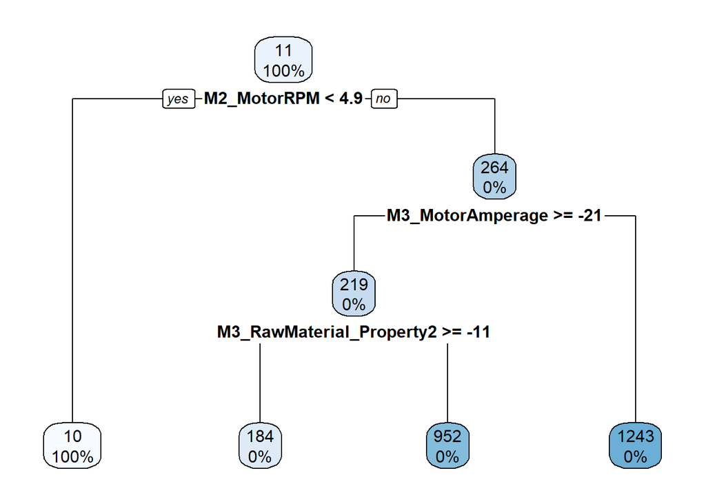

```r
rpart.plot(dt[[1]]$finalModel)
```

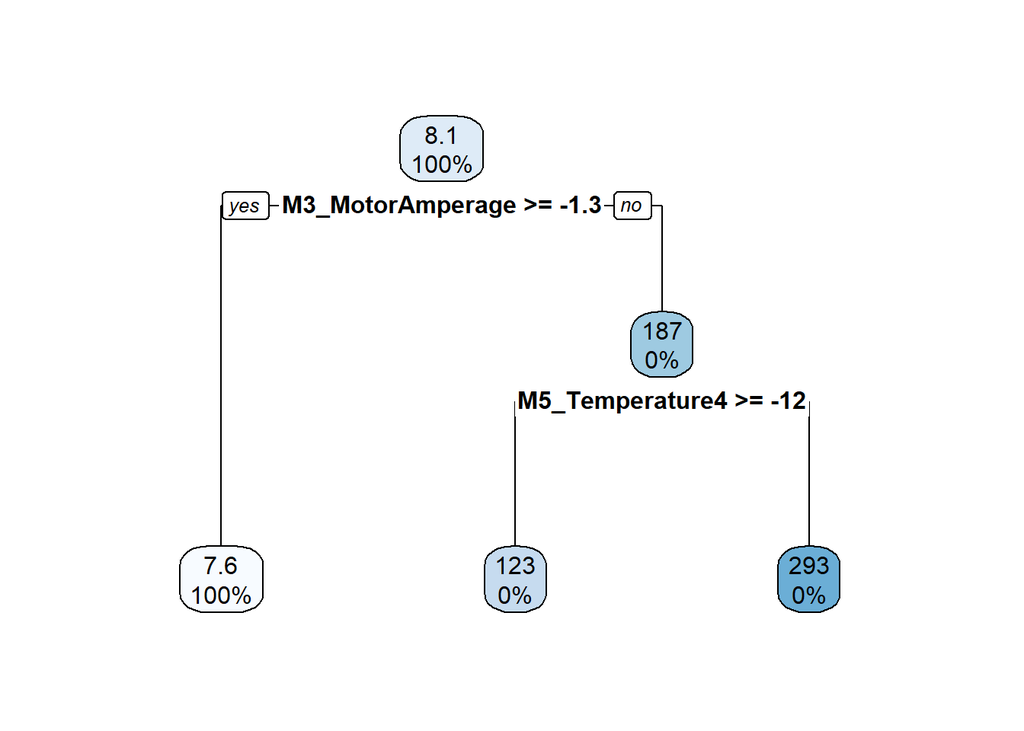

```r
rpart.plot(dt[[2]]$finalModel)
```

```r
#SVR
library(e1071)
support_vector <- function(train1, train2){
  svm_grid <- expand.grid(.C=c(0.1,1,10), .sigma=c(0.01,0.05,0.1))

  svr1 <- train(Stage1_Output ~ ., data=train1, method="svmRadial",
              trControl=train_control, tuneGrid=svm_grid)
  using1 <- predict(svr1, newdata=train1)
  trainsc2$stage1_ouput_exp <- using1
  svr2 <- train(Stage2_Output ~ ., data=train2, method="svmRadial",
              trControl=train_control, tuneGrid=svm_grid)

  return(list(svr1,svr2))
}

svr <- support_vector(trainsc1, trainsc2)
svrpca <- support_vector(train1pca, train2pca)

#ANN
library(nnet)
multi_perceptron <- function(train1, train2){
  mlp_gird <- expand.grid(.size=c(1,3,5), .decay=c(0,0.001,0.01))
  mlp1 <- train(Stage1_Output ~ ., data=train1, method="nnet",
              trControl=train_control, tuneGrid=mlp_gird,
              linout = T, trace = T)
  using1 <- predict(mlp1$finalModel, newdata=train1)
  if (is.matrix(using1)) {
    using1 <- as.vector(using1)  # 예측 결과를 벡터로 변환
  }
  trainsc2$stage1_ouput_exp <- using1
  mlp2 <- train(Stage2_Output ~ ., data=train2, method="nnet",
              trControl=train_control, tuneGrid=mlp_gird,
              linout = T, trace = T)
  return(list(mlp1, mlp2))
}

mlp <- multi_perceptron(trainsc1, trainsc2)
mlppca <- multi_perceptron(train1pca, train2pca)
# 적합 모델간 지표 평가
model_name = c("Decistion Tree","Support Vector","MLP")
model_list = list(dt, svr, mlp, dtpca, svrpca, mlppca)

results <- list()

for(i in seq_len(3)){
  model <- model_list[[i]]
  modelpca <- model_list[[i+3]]
  eval <- evaluate(model_name[i], model[[1]], model[[2]], testsc1, testsc2)
  results[[length(results) + 1]] <- eval

  eval <- evaluate(paste(model_name[i], "pca"), modelpca[[1]], modelpca[[2]], test1pca, test2pca)
  results[[length(results) + 1]] <- eval
}
```

```
## [1] "Decistion Tree"
##              Model         Stage1 MAE        Stage1 RMSE         Stage1 MSE
##   "Decistion Tree" "1.73500310908176" "24.0055539115585"  "576.26661860074"
##         Stage2 MAE        Stage2 RMSE         Stage2 MSE
## "1.24209784661917" "7.85627963187422" "61.7211296542018"
## [1] "Decistion Tree pca"
##                Model           Stage1 MAE          Stage1 RMSE
## "Decistion Tree pca"   "1.28589045856589"   "8.82160351204845"
##           Stage1 MSE           Stage2 MAE          Stage2 RMSE
##   "77.8206885237855"   "1.25411008985511"    "7.6797466195229"
##           Stage2 MSE
##   "58.9785081400734"
## [1] "Support Vector"
##               Model          Stage1 MAE         Stage1 RMSE          Stage1 MSE
##    "Support Vector"  "1.27457091007795"  "7.51018338766143"  "56.4028545163058"
##          Stage2 MAE         Stage2 RMSE          Stage2 MSE
## "0.959205661016123"   "7.1709310810693"  "51.4222525694457"
## [1] "Support Vector pca"
##                Model           Stage1 MAE          Stage1 RMSE
## "Support Vector pca"   "1.41803797096479"   "7.50255291538261"
##           Stage1 MSE           Stage2 MAE          Stage2 RMSE
##   "56.2883002481161"   "1.05809333879386"   "7.24514023489824"
##           Stage2 MSE
##   "52.4920570233414"
## [1] "MLP"
##              Model         Stage1 MAE        Stage1 RMSE         Stage1 MSE
##              "MLP" "1.12988044995114" "7.26933063874574" "52.8431679354075"
##         Stage2 MAE        Stage2 RMSE         Stage2 MSE
## "1.27815714154815" "7.83474031587293" "61.3831558171647"
## [1] "MLP pca"
##              Model         Stage1 MAE        Stage1 RMSE         Stage1 MSE
##          "MLP pca" "1.32614115684828" "9.33118920821916" "87.0710920395858"
##         Stage2 MAE        Stage2 RMSE         Stage2 MSE
## "1.09409727381158" "8.08106497340998" "65.3036111044736"
```

```r
results_df <- do.call(rbind, lapply(results, function(x) as.data.frame(t(x), stringsAsFactors = FALSE)))
colnames(results_df) <- c("Model", "Stage1_MAE", "Stage1_RMSE", "Stage1_MSE",
                          "Stage2_MAE", "Stage2_RMSE", "Stage2_MSE")
results_df_sorted <- results_df[order(results_df$Stage2_RMSE), ]
results_df_sorted <- data.frame(Index = seq_len(nrow(results_df_sorted)), results_df_sorted)

# 결과 출력
print(results_df_sorted)
```

```
##   Index              Model       Stage1_MAE      Stage1_RMSE       Stage1_MSE
## 3     1     Support Vector 1.27457091007795 7.51018338766143 56.4028545163058
## 4     2 Support Vector pca 1.41803797096479 7.50255291538261 56.2883002481161
## 2     3 Decistion Tree pca 1.28589045856589 8.82160351204845 77.8206885237855
## 5     4                MLP 1.12988044995114 7.26933063874574 52.8431679354075
## 1     5     Decistion Tree 1.73500310908176 24.0055539115585  576.26661860074
## 6     6            MLP pca 1.32614115684828 9.33118920821916 87.0710920395858
##          Stage2_MAE      Stage2_RMSE       Stage2_MSE
## 3 0.959205661016123  7.1709310810693 51.4222525694457
## 4  1.05809333879386 7.24514023489824 52.4920570233414
## 2  1.25411008985511  7.6797466195229 58.9785081400734
## 5  1.27815714154815 7.83474031587293 61.3831558171647
## 1  1.24209784661917 7.85627963187422 61.7211296542018
## 6  1.09409727381158 8.08106497340998 65.3036111044736
```

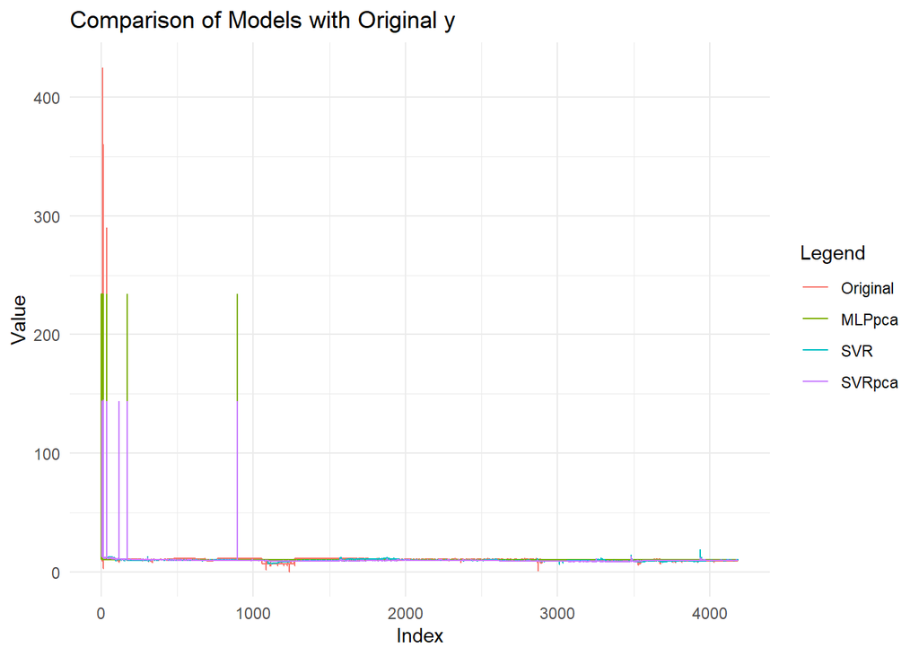

```r
library(ggplot2)
library(reshape2)

y <- test1pca$Stage1_Output
Model1 <- predict(mlppca[[1]], newdata=test1pca)
Model2 <- predict(svr[[1]], newdata=testsc1)
Model3 <- predict(svrpca[[1]], newdata=test1pca)

df_pred <- data.frame(Index = 1:4185, Original = y, MLPpca = Model1, SVR = Model2, SVRpca = Model3)

df_long <- melt(df_pred, id.vars = "Index")

# 플롯 생성
ggplot(df_long, aes(x = Index, y = value, color = variable)) +
  geom_line() +
  labs(title = "Comparison of Models with Original y",
       x = "Index",
       y = "Value",
       color = "Legend") +
  theme_minimal()
```

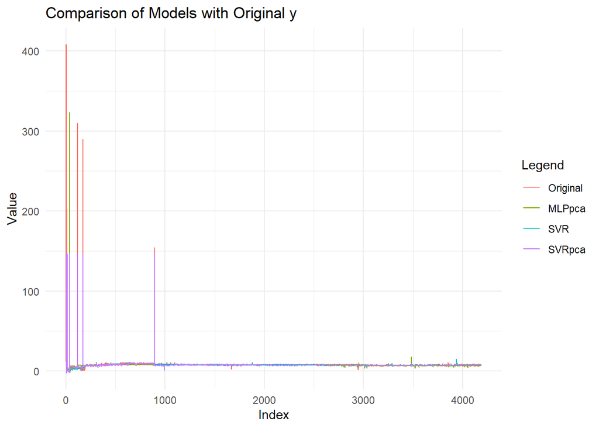

```r
y <- test2pca$Stage2_Output
Model1 <- predict(mlppca[[2]], newdata=test2pca)
Model2 <- predict(svr[[2]], newdata=testsc2)
Model3 <- predict(svrpca[[2]], newdata=test2pca)

df_pred <- data.frame(Index = 1:4185, Original = y, MLPpca = Model1, SVR = Model2, SVRpca = Model3)

df_long <- melt(df_pred, id.vars = "Index")

# 플롯 생성
ggplot(df_long, aes(x = Index, y = value, color = variable)) +
  geom_line() +
  labs(title = "Comparison of Models with Original y",
       x = "Index",
       y = "Value",
       color = "Legend") +
  theme_minimal()
```